[O’Hara on GitHub](https://github.com/oharac)

# Compare sensitivity of species vulnerability from traits

Compiled on Thu Aug 12 11:43:18 2021 by ohara

```r
knitr::opts_chunk$set(fig.width = 6, fig.height = 4, fig.path = 'figs/',
                      echo = TRUE, message = FALSE, warning = FALSE)

library(oharac) ### remotes::install_github('oharac/oharac')
oharac::setup()
source(here('common_fxns.R'))
options(dplyr.summarise.inform = FALSE)
```

# 1 Summary

*NOTE: Run this after script 4 (4_downstream_taxa_vuln.Rmd) because the downfilled species list from that script is used in this script to expand taxonomic groups before estimating RMSE of rank shift.*

Duplicates analysis of `2_calculate_spp_gp_vuln.Rmd` but with different scoring distributions to compare sensitivity of results to choice of scoring scheme. The original scoring scheme is:

- none/NA: 0
- low: .33
- medium: .67
- high: 1.00

The convex scoring scheme is based on squaring these values (none and high are unchanged, 0/1)

- low: $.33^2$ = .11
- medium: $.67^2$ = .45

The concave scoring scheme is based on square root of these values:

- low: $\sqrt{.33}$ = .57
- medium: $\sqrt{.67}$ = .82

Checks are dropped. Habitat destruction stressor is ignored for simplicity.

# 2 Data

Same as `2_calculate_spp_gp_vuln.Rmd`

# 3 Methods

## 3.1 Read in and clean species traits

Set up a function to consistently clean trait values. Trait values in the species trait file are already cleaned and adjusted in many cases to get around mismatches; they are generally lower case, no punctuation except for greater/less than signs.

This function also cleans up category and trait names for consistency. All lower case, punctuation and spaces replaced with underscores. The species trait file is already cleaned in this manner.

```r
clean_traitnames <- function(df, overwrite_clean_col = FALSE) {
  df <- df %>%
    mutate(category = str_replace_all(category, '[^A-Za-z0-9]+', '_') %>% tolower(),
           category = str_replace_all(category, '^_|_$', ''),
           trait    = str_replace_all(trait, '[^A-Za-z0-9]+', '_') %>% tolower(),
           trait    = str_replace_all(trait, '^_|_$', ''))
  if(!overwrite_clean_col & ('trait_value' %in% names(df))) {
      return(df) ### without overwriting existing trait_value
  }
  if(overwrite_clean_col & ('trait_value' %in% names(df))) {
    x <- readline(prompt = 'Overwriting existing trait_value column? y/n ')
    if(str_detect(x, '^n')) stop('dammit!')
  }
  ### overwrite existing, or add new
  df <- df %>%
    mutate(trait_value = str_replace_all(tolower(trait_value), '[^0-9a-z<>]', ''))

  return(df)
}

clean_traitvals <- function(df) {
  x <- df$trait_value
  ### First: remove numeric commas
  y <- str_replace_all(x, '(?<=[0-9]),(?=[0-9])', '') %>%
    ### then: drop all non-alphanumeric and a few key punctuation:
    str_replace_all('[^0-9a-zA-Z<>,;\\-\\.\\(\\)/ ]', '') %>%
    ### lower case; do it after dropping any weird non-ascii characters:
    tolower() %>%
    str_trim() %>%
    str_replace_all('n/a', 'na') %>%
    ### convert remaining commas and slashes to semicolons:
    str_replace_all('[,/]', ';') %>%
    ### drop spaces after numbers e.g. 3 mm -> 3mm:
    str_replace_all('(?<=[0-9]) ', '') %>%
    ### drop spaces before or after punctuation (non-alphanumeric):
    str_replace_all(' (?=[^a-z0-9\\(])|(?<=[^a-z0-9\\)]) ', '') %>%
    ### manually fix some valid slashes:
    str_replace_all('nearly sessile;sedentary', 'nearly sessile/sedentary') %>%
    str_replace_all('live birth;egg care', 'live birth/egg care') %>%
    str_replace_all('chitin;caco3mix', 'chitin/caco3 mix') %>%
    str_replace_all('0.5-49mm', '0.5mm-49mm')

  df$trait_value <- y
  return(df)
}

assign_rank_scores <- function(x, shape = 'linear') {
  lo <- case_when(shape == 'linear'  ~ .33,
                  shape == 'concave' ~ .57,
                  shape == 'convex'  ~ .11)
  md <- case_when(shape == 'linear'  ~ .67,
                  shape == 'concave' ~ .82,
                  shape == 'convex'  ~ .45)
  hi <- 1
  y <- tolower(as.character(x))
  z <- case_when(!is.na(as.numeric(x)) ~ as.numeric(x),
                 str_detect(y, '^na')  ~ 0.00,
                 str_detect(y, '^n')   ~ 0.00, ### none, NA, no
                 str_detect(y, '^lo')  ~ lo,
                 str_detect(y, '^med') ~ md,
                 str_detect(y, '^hi')  ~ hi,
                 str_detect(y, '^y')   ~ hi, ### yes
                 TRUE                  ~ NA_real_) ### basically NA
  return(z)
}
```

Since the species trait file is already cleaned, DO NOT use the `clean_traitvals` function - it will overwrite the `trait_value` column. Here we will drop plants and algae as physiologies are so fundamentally different from animals.

```r
spp_traits <- read_csv('_data/spp_traits_valid.csv') %>%
  filter(taxon != 'plants_algae')
```

```r
str_trait_f <- here('_raw_data/xlsx',
                    'stressors_traits_scored.xlsx')
str_trait_shts <- readxl::excel_sheets(str_trait_f)
```

## 3.2 Calculate sensitivity scores

Note for simplicity we will drop the sensitivity to habitat destruction…

### 3.2.1 Calculate for all

```r
sens_traits_raw <- readxl::read_excel(str_trait_f, sheet = 'sensitivity')
```

```r
sens_traits_conv <- sens_traits_raw %>%
  janitor::clean_names() %>%
  gather(stressor, sens_score, -category, -trait, -trait_value) %>%
  mutate(sens_score_orig = as.character(sens_score),
         sens_score = assign_rank_scores(sens_score, shape = 'convex')) %>%
  clean_traitnames() %>%
  clean_traitvals() %>%
  filter(!is.na(category))

str_sens_trait_conv <- sens_traits_conv %>%
  select(category, trait, trait_value, sens_score, stressor) %>%
  mutate(sens_score = ifelse(is.na(sens_score), 0, sens_score)) %>%
  filter(!is.na(trait))

spp_sens_conv_raw <- str_sens_trait_conv %>%
  left_join(spp_traits %>% filter(!str_detect(trait, 'dependent_habitat')),
            by = c('category', 'trait', 'trait_value')) %>%
  filter(!is.na(stressor) & !is.na(taxon))

spp_sens_conv <- spp_sens_conv_raw %>%
  group_by(spp_gp, stressor, taxon, trait) %>%
  summarize(sens_score = sum(sens_score * trait_prob, na.rm = TRUE)) %>%
  group_by(spp_gp, stressor, taxon) %>%
  summarize(sens_score = sum(sens_score, na.rm = TRUE), .groups = 'drop')
```

```r
sens_traits_conc <- sens_traits_raw %>%
  janitor::clean_names() %>%
  gather(stressor, sens_score, -category, -trait, -trait_value) %>%
  mutate(sens_score_orig = as.character(sens_score),
         sens_score = assign_rank_scores(sens_score, shape = 'concave')) %>%
  clean_traitnames() %>%
  clean_traitvals() %>%
  filter(!is.na(category))

str_sens_trait_conc <- sens_traits_conc %>%
  select(category, trait, trait_value, sens_score, stressor) %>%
  mutate(sens_score = ifelse(is.na(sens_score), 0, sens_score)) %>%
  filter(!is.na(trait))

spp_sens_conc_raw <- str_sens_trait_conc %>%
  left_join(spp_traits %>% filter(!str_detect(trait, 'dependent_habitat')),
            by = c('category', 'trait', 'trait_value')) %>%
  filter(!is.na(stressor) & !is.na(taxon))

spp_sens_conc <- spp_sens_conc_raw %>%
  group_by(spp_gp, stressor, taxon, trait) %>%
  summarize(sens_score = sum(sens_score * trait_prob, na.rm = TRUE)) %>%
  group_by(spp_gp, stressor, taxon) %>%
  summarize(sens_score = sum(sens_score, na.rm = TRUE), .groups = 'drop')
```

## 3.3 Score general adaptive capacity

```r
adcap_gen_traits_raw <- readxl::read_excel(str_trait_f, sheet = 'gen_adcap')
```

```r
adcap_gen_traits_conv <- adcap_gen_traits_raw %>%
  select(category, trait, trait_value, adcap_score) %>%
  # filter(trait != 'max age' & trait != 'if one/few, size') %>%
  mutate(adcap_score_orig = as.character(adcap_score),
         adcap_score = assign_rank_scores(adcap_score, shape = 'convex')) %>%
  clean_traitnames() %>%
  clean_traitvals()

spp_adcap_gen_conv_raw <- spp_traits %>%
  left_join(adcap_gen_traits_conv, by = c('category', 'trait', 'trait_value')) %>%
  mutate(adcap_gen_score = ifelse(is.na(adcap_score), 0, adcap_score)) %>%
  select(-n_spp_gps, -adcap_score, -adcap_score_orig)

spp_adcap_gen_conv <- spp_adcap_gen_conv_raw %>%
  group_by(spp_gp, taxon, trait) %>%
  summarize(adcap_gen_score = sum(adcap_gen_score * trait_prob, na.rm = TRUE)) %>%
  group_by(spp_gp, taxon) %>%
  summarize(adcap_gen_score = sum(adcap_gen_score, na.rm = TRUE),
            .groups = 'drop')
```

```r
adcap_gen_traits_conc <- adcap_gen_traits_raw %>%
  select(category, trait, trait_value, adcap_score) %>%
  # filter(trait != 'max age' & trait != 'if one/few, size') %>%
  mutate(adcap_score_orig = as.character(adcap_score),
         adcap_score = assign_rank_scores(adcap_score, shape = 'concave')) %>%
  clean_traitnames() %>%
  clean_traitvals()

spp_adcap_gen_conc_raw <- spp_traits %>%
  left_join(adcap_gen_traits_conc, by = c('category', 'trait', 'trait_value')) %>%
  mutate(adcap_gen_score = ifelse(is.na(adcap_score), 0, adcap_score)) %>%
  select(-n_spp_gps, -adcap_score, -adcap_score_orig)

spp_adcap_gen_conc <- spp_adcap_gen_conc_raw %>%
  group_by(spp_gp, taxon, trait) %>%
  summarize(adcap_gen_score = sum(adcap_gen_score * trait_prob, na.rm = TRUE)) %>%
  group_by(spp_gp, taxon) %>%
  summarize(adcap_gen_score = sum(adcap_gen_score, na.rm = TRUE),
            .groups = 'drop')
```

## 3.4 Score specific adaptive capacity

```r
adcap_spec_traits_raw <- readxl::read_excel(str_trait_f, sheet = 'spec_adcap') %>%
  janitor::clean_names() %>%
  filter(!str_detect(tolower(category), 'spatial')) ### drop exposure traits
```

```r
adcap_spec_traits_conv <- adcap_spec_traits_raw %>%
  janitor::clean_names() %>%
  gather(stressor, adcap_score, -category, -trait, -trait_value) %>%
  mutate(adcap_score_orig = as.character(adcap_score),
         adcap_score = assign_rank_scores(adcap_score, shape = 'convex')) %>%
  clean_traitnames() %>%
  clean_traitvals() %>%
  filter(!is.na(trait))

spp_adcap_spec_conv_raw <- spp_traits %>%
  left_join(adcap_spec_traits_conv, by = c('category', 'trait', 'trait_value')) %>%
  mutate(adcap_spec_score = ifelse(is.na(adcap_score), 0, adcap_score)) %>%
  filter(!is.na(stressor))

spp_adcap_spec_conv <- spp_adcap_spec_conv_raw %>%
  select(-n_spp_gps, -adcap_score, -adcap_score_orig) %>%
  group_by(spp_gp, stressor, taxon, trait) %>%
  summarize(adcap_spec_score = sum(adcap_spec_score * trait_prob, na.rm = TRUE)) %>%
  group_by(spp_gp, stressor, taxon) %>%
  summarize(adcap_spec_score = sum(adcap_spec_score, na.rm = TRUE),
            .groups = 'drop')
```

```r
adcap_spec_traits_conc <- adcap_spec_traits_raw %>%
  janitor::clean_names() %>%
  gather(stressor, adcap_score, -category, -trait, -trait_value) %>%
  mutate(adcap_score_orig = as.character(adcap_score),
         adcap_score = assign_rank_scores(adcap_score, shape = 'concave')) %>%
  clean_traitnames() %>%
  clean_traitvals() %>%
  filter(!is.na(trait))

spp_adcap_spec_conc_raw <- spp_traits %>%
  left_join(adcap_spec_traits_conc, by = c('category', 'trait', 'trait_value')) %>%
  mutate(adcap_spec_score = ifelse(is.na(adcap_score), 0, adcap_score)) %>%
  filter(!is.na(stressor))

spp_adcap_spec_conc <- spp_adcap_spec_conc_raw %>%
  select(-n_spp_gps, -adcap_score, -adcap_score_orig) %>%
  group_by(spp_gp, stressor, taxon, trait) %>%
  summarize(adcap_spec_score = sum(adcap_spec_score * trait_prob, na.rm = TRUE)) %>%
  group_by(spp_gp, stressor, taxon) %>%
  summarize(adcap_spec_score = sum(adcap_spec_score, na.rm = TRUE),
            .groups = 'drop')
```

## 3.5 Assign exposure potential modifier

Exposure potential modifier checks whether the depth and oceanic zones of the stressor match with the depth and oceanic zones of the species. These fall into the “spatial scale” category with the exception of EOO. Exposure is not related to the scaling of none-low-medium-high so no change is necessary.

```r
exp_traits_raw <- readxl::read_excel(str_trait_f, sheet = 'spec_adcap') %>%
  filter(str_detect(tolower(category), 'spatial')) ### include only exposure traits

exp_traits <- exp_traits_raw %>%
  janitor::clean_names() %>%
  gather(stressor, exp_score, -category, -trait, -trait_value) %>%
  mutate(exp_score_orig = as.character(exp_score),
         exp_score = assign_rank_scores(exp_score)) %>%
  clean_traitnames()

### wildlife strike calculated separately to avoid spurious exposure of
### benthic/intertidal critters
spp_exposure_raw <- spp_traits %>%
  inner_join(exp_traits, by = c('category', 'trait', 'trait_value')) %>%
  filter(stressor != 'wildlife_strike') %>%
  group_by(spp_gp, stressor, taxon) %>%
  summarize(exposure_mod = as.integer(sum(exp_score, na.rm = TRUE) > 0),
            .groups = 'drop') %>%
  arrange(stressor, taxon)

air_sea <- spp_traits %>%
  filter(trait == 'air_sea_interface' & trait_value != 'no') %>%
  .$spp_gp %>% unique()
spp_exposure_wildlife_strike <- spp_traits %>%
  inner_join(exp_traits, by = c('category', 'trait', 'trait_value')) %>%
  filter(stressor == 'wildlife_strike') %>%
  group_by(spp_gp, taxon) %>%
  summarize(exposure_mod = as.integer(sum(exp_score, na.rm = TRUE) > 0),
            zone = paste(trait_value, collapse = ';'),
            .groups = 'drop') %>%
  mutate(btm_only = str_detect(zone, 'benthic|demersal') &
                    !str_detect(zone, 'oceanic|air') &
                    !spp_gp %in% air_sea,
         intertidal_only = str_detect(zone, 'intertidal') & !str_detect(zone, 'neritic|oceanic'),
         taxon_excl = taxon %in% c('crustacea_arthropods', 'molluscs'),
         clear = btm_only|intertidal_only|taxon_excl) %>%
  mutate(override = exposure_mod > 0 & clear,
         exposure_mod = ifelse(clear, 0, exposure_mod),
         stressor = 'wildlife_strike')

spp_exposure <- spp_exposure_wildlife_strike %>%
  select(spp_gp, taxon, exposure_mod, stressor) %>%
  bind_rows(spp_exposure_raw)

non_exposures <- spp_exposure %>%
  group_by(taxon, stressor) %>%
  mutate(n_gps = n_distinct(spp_gp)) %>%
  filter(exposure_mod == 0) %>%
  summarize(n_gps_no_exp = n_distinct(spp_gp),
            n_gps = first(n_gps),
            pct_no_exp = round(n_gps_no_exp / n_gps, 3),
            .groups = 'drop') %>%
  arrange(stressor, desc(n_gps_no_exp))

null_exposures <- spp_traits %>%
  select(spp_gp, taxon) %>%
  anti_join(spp_exposure, by = c('spp_gp', 'taxon')) %>%
  distinct()

cleared_exposure <- spp_exposure_wildlife_strike %>%
  filter(override)

write_csv(cleared_exposure, 'int/cleared_exposure.csv')
```

# 4 Combine scores for convex scoring

```r
rescale_vals <- function(x, ref_values) {
  z <- x %>%
    left_join(ref_values, by = 'stressor') %>%
    mutate(sens_rescale = sens_score / max_sens,
           acg_rescale  = adcap_gen_score / max_adcap_gen,
           acs_rescale =  adcap_spec_score / max_adcap_spec)
  return(z)
}
calc_vuln <- function(x, ref_values) {
  zz <- x %>%
    rescale_vals(ref_values) %>%
    mutate(vuln_raw = sens_rescale / (1 + acg_rescale + acs_rescale))
  return(zz)
}
```

```r
conv_score_file <- here('int/spp_gp_vuln_convex_scoring.csv')

if(!file.exists(conv_score_file)) {
  spp_scores_conv_mean <- spp_sens_conv %>%
    left_join(spp_adcap_gen_conv, by = c('taxon', 'spp_gp')) %>%
    left_join(spp_adcap_spec_conv, by = c('taxon', 'spp_gp', 'stressor'))

  ref_values_conv <- spp_scores_conv_mean %>%
    group_by(stressor) %>%
    summarize(max_sens = max(sens_score, 1),
                ### the 1 ensures that stressors with very low scores don't get normalized by a low reference
              max_adcap_gen = max(adcap_gen_score, 1),
              max_adcap_spec = max(adcap_spec_score, 1),
              .groups = 'drop')

  ### Separate deterministic spp (all traits fixed) from those for Monte Carlo
  spp_sens_conv_det <- spp_sens_conv_raw %>%
    group_by(spp_gp) %>%
    filter(all(trait_prob == 1)) %>%
    .$spp_gp %>% unique()

  spp_adcap_spec_conv_det <- spp_adcap_spec_conv_raw %>%
    group_by(spp_gp) %>%
    filter(all(trait_prob == 1)) %>%
    .$spp_gp %>% unique()

  spp_adcap_gen_conv_det <- spp_adcap_gen_conv_raw %>%
    group_by(spp_gp) %>%
    filter(all(trait_prob == 1)) %>%
    .$spp_gp %>% unique()

  ### to be fully determined, a species must be fixed in sensitivity and both adcaps
  spp_conv_deterministic <- spp_sens_conv_det[(spp_sens_conv_det %in% spp_adcap_spec_conv_det) &
                                      (spp_sens_conv_det %in% spp_adcap_gen_conv_det)]
  spp_scores_conv_det <- spp_scores_conv_mean %>%
    filter(spp_gp %in% spp_conv_deterministic)
}
```

```r
if(!file.exists(conv_score_file)) {
  ### For Monte Carlo spp, for each spp, draw a bunch of samples from pool of
  ### possible values

  set.seed(42)
  iters <- 100000

  ### empty set fill
  empty_set <- crossing(stressor = spp_sens_conv$stressor %>% unique(),
                        n = 1:iters)

  spp_conv_mc <- spp_sens_conv %>%
    filter(!spp_gp %in% spp_conv_deterministic) %>%
    .$spp_gp %>% unique()


  spp_conv_mc_vuln_list <- parallel::mclapply(seq_along(spp_conv_mc), mc.cores = 30,
    FUN = function(i) {
      ### spp <- 'pelecanidae'
      spp <- spp_conv_mc[i]

      traits <- spp_traits %>%
        filter(spp_gp == spp) %>%
        select(-n_spp_gps)
      taxon <- traits$taxon[1]

      ### separate out single and non-mutually-exclusive traits; include all values
      traits_det <- traits %>%
        filter(trait_prob == 1)
      ### Identify mutually exclusive traits; tally up # of combos
      traits_multi <- traits %>%
        filter(trait_prob != 1)

      ### filter sens and adcap dfs out of the loop
      sens_clean <- spp_sens_conv_raw %>%
        filter(spp_gp == spp) %>%
        select(trait, trait_value, sens_score, stressor)
      sens_clean_det <- sens_clean %>%
        filter(trait %in% traits_det$trait)
      sens_clean_multi <- sens_clean %>%
        filter(trait %in% traits_multi$trait)

      acg_clean <- spp_adcap_gen_conv_raw %>%
        filter(spp_gp == spp) %>%
        select(trait, trait_value, adcap_gen_score)
      acg_clean_det <- acg_clean %>%
        filter(trait %in% traits_det$trait)
      acg_clean_multi <- acg_clean %>%
        filter(trait %in% traits_multi$trait)

      acs_clean <- spp_adcap_spec_conv_raw %>%
        filter(spp_gp == spp) %>%
        select(trait, trait_value, adcap_spec_score, stressor)
      acs_clean_det <- acs_clean %>%
        filter(trait %in% traits_det$trait)
      acs_clean_multi <- acs_clean %>%
        filter(trait %in% traits_multi$trait)

      message('Processing ', i, ' of ', length(spp_conv_mc), ': ', spp,
              ' (running ', iters, ' iterations)')

      ### process sensitivity traits
      sens_score_det <- sens_clean_det %>%
        group_by(stressor) %>%
        summarize(sens_score_det = sum(sens_score), .groups = 'drop')

      if(nrow(sens_clean_multi) > 0) {
        spp_sens_sample <- sens_clean_multi %>%
          group_by(trait, stressor) %>%
          summarize(score_samp = list(sample(sens_score, size = iters, replace = TRUE)),
                    .groups = 'keep') %>%
          unnest(score_samp) %>%
          mutate(n = 1:n()) %>%
          group_by(stressor, n) %>%
          summarize(sens_score_random = sum(score_samp), .groups = 'drop') %>%
          left_join(sens_score_det, by = 'stressor')
      } else {
        spp_sens_sample <- sens_score_det %>%
          mutate(sens_score_random = 0) %>%
          left_join(empty_set, by = 'stressor')
      }

      ### process specific adcap traits
      acs_score_det <- acs_clean_det %>%
        group_by(stressor) %>%
        summarize(acs_score_det = sum(adcap_spec_score), .groups = 'drop')

      if(nrow(acs_clean_multi) > 0) {
        spp_acs_sample <- acs_clean_multi %>%
          group_by(trait, stressor) %>%
          summarize(score_samp = list(sample(adcap_spec_score, size = iters, replace = TRUE)),
                    .groups = 'keep') %>%
          unnest(score_samp) %>%
          mutate(n = 1:n()) %>%
          group_by(stressor, n) %>%
          summarize(acs_score_random = sum(score_samp), .groups = 'drop') %>%
          left_join(acs_score_det, by = 'stressor')

      } else {
        spp_acs_sample <- acs_score_det %>%
          mutate(acs_score_random = 0) %>%
          left_join(empty_set, by = 'stressor')
      }

      ### process general adcap traits
      acg_score_det <- acg_clean_det %>%
        summarize(acg_score_det = sum(adcap_gen_score))

      if(nrow(acg_clean_multi) > 0) {
        spp_acg_sample <- acg_clean_multi %>%
          group_by(trait) %>%
          summarize(score_samp = list(sample(adcap_gen_score, size = iters, replace = TRUE)),
                    .groups = 'keep') %>%
          unnest(score_samp) %>%
          mutate(n = 1:n()) %>%
          group_by(n) %>%
          summarize(acg_score_random = sum(score_samp), .groups = 'drop') %>%
          mutate(acg_score_det = acg_score_det$acg_score_det)

      } else {
        spp_acg_sample <- data.frame(n = 1:iters,
                                     acg_score_det = acg_score_det$acg_score_det,
                                     acg_score_random = 0)
      }

      spp_scores_sample <- spp_sens_sample %>%
        left_join(spp_acs_sample, by = c('stressor', 'n')) %>%
        left_join(spp_acg_sample, by = 'n') %>%
        mutate(sens_score = sens_score_random + sens_score_det,
               adcap_gen_score = acg_score_det + acg_score_random,
               adcap_spec_score = acs_score_random + acs_score_det) %>%
        select(-ends_with('random'), -ends_with('det'))

      ### gather iterations and calculate distributions
      x <- spp_scores_sample %>%
        calc_vuln(ref_values = ref_values_conv) %>%
        group_by(stressor) %>%
        summarize(sd_sens = sd(sens_score),
                  sens_score = mean(sens_score),
                  sd_acg = sd(adcap_gen_score),
                  adcap_gen_score = mean(adcap_gen_score),
                  sd_acs = sd(adcap_spec_score),
                  adcap_spec_score = mean(adcap_spec_score),
                  sd_vuln = sd(vuln_raw),
                  vuln_raw = mean(vuln_raw),
                  .groups = 'drop') %>%
        mutate(taxon = taxon, spp_gp = spp)

      return(x)
    })

  spp_vuln_conv_mc <- bind_rows(spp_conv_mc_vuln_list)
}
```

```r
if(!file.exists(conv_score_file)) {
  spp_vuln_conv_all <- spp_scores_conv_mean %>%
    filter(!spp_gp %in% spp_conv_mc) %>%
    calc_vuln(ref_values = ref_values_conv) %>%
    bind_rows(spp_vuln_conv_mc) %>%
    select(taxon, spp_gp, stressor,
           sens_score, adcap_gen_score, adcap_spec_score,
           vuln_raw, sd_sens, sd_acg, sd_acs, sd_vuln_raw = sd_vuln) %>%
    left_join(spp_exposure, by = c('spp_gp', 'taxon', 'stressor')) %>%
    mutate(vuln_raw = vuln_raw * exposure_mod,
           sd_vuln_raw = sd_vuln_raw * exposure_mod) %>%
    distinct()

  spp_vuln_conv_rescale <- spp_vuln_conv_all %>%
    ungroup() %>%
    filter(stressor != 'habitat_loss_degradation') %>%
    mutate(vuln = vuln_raw / max(vuln_raw),
           sd_vuln = sd_vuln_raw / max(vuln_raw)) %>%
    arrange(desc(sd_vuln))

  write_csv(spp_vuln_conv_rescale, conv_score_file)
}
```

# 5 Combine scores for concave scoring

```r
conc_score_file <- here('int/spp_gp_vuln_concave_scoring.csv')

if(!file.exists(conc_score_file)) {
  spp_scores_conc_mean <- spp_sens_conc %>%
    left_join(spp_adcap_gen_conc, by = c('taxon', 'spp_gp')) %>%
    left_join(spp_adcap_spec_conc, by = c('taxon', 'spp_gp', 'stressor'))

  ref_values_conc <- spp_scores_conc_mean %>%
    group_by(stressor) %>%
    summarize(max_sens = max(sens_score, 1),
                ### the 1 ensures that stressors with very low scores don't get normalized by a low reference
              max_adcap_gen = max(adcap_gen_score, 1),
              max_adcap_spec = max(adcap_spec_score, 1),
              .groups = 'drop')

  ### Separate deterministic spp (all traits fixed) from those for Monte Carlo
  spp_sens_conc_det <- spp_sens_conc_raw %>%
    group_by(spp_gp) %>%
    filter(all(trait_prob == 1)) %>%
    .$spp_gp %>% unique()

  spp_adcap_spec_conc_det <- spp_adcap_spec_conc_raw %>%
    group_by(spp_gp) %>%
    filter(all(trait_prob == 1)) %>%
    .$spp_gp %>% unique()

  spp_adcap_gen_conc_det <- spp_adcap_gen_conc_raw %>%
    group_by(spp_gp) %>%
    filter(all(trait_prob == 1)) %>%
    .$spp_gp %>% unique()

  ### to be fully determined, a species must be fixed in sensitivity and both adcaps
  spp_conc_deterministic <- spp_sens_conc_det[(spp_sens_conc_det %in% spp_adcap_spec_conc_det) &
                                      (spp_sens_conc_det %in% spp_adcap_gen_conc_det)]
  spp_scores_conc_det <- spp_scores_conc_mean %>%
    filter(spp_gp %in% spp_conc_deterministic)
}
```

```r
if(!file.exists(conc_score_file)) {
  ### For Monte Carlo spp, for each spp, draw a bunch of samples from pool of
  ### possible values

  set.seed(42)
  iters <- 100000

  ### empty set fill
  empty_set <- crossing(stressor = spp_sens_conc$stressor %>% unique(),
                        n = 1:iters)

  spp_conc_mc <- spp_sens_conc %>%
    filter(!spp_gp %in% spp_conc_deterministic) %>%
    .$spp_gp %>% unique()


  spp_conc_mc_vuln_list <- parallel::mclapply(seq_along(spp_conc_mc), mc.cores = 30,
    FUN = function(i) {
      ### spp <- 'pelecanidae'
      spp <- spp_conc_mc[i]

      traits <- spp_traits %>%
        filter(spp_gp == spp) %>%
        select(-n_spp_gps)
      taxon <- traits$taxon[1]

      ### separate out single and non-mutually-exclusive traits; include all values
      traits_det <- traits %>%
        filter(trait_prob == 1)
      ### Identify mutually exclusive traits; tally up # of combos
      traits_multi <- traits %>%
        filter(trait_prob != 1)

      ### filter sens and adcap dfs out of the loop
      sens_clean <- spp_sens_conc_raw %>%
        filter(spp_gp == spp) %>%
        select(trait, trait_value, sens_score, stressor)
      sens_clean_det <- sens_clean %>%
        filter(trait %in% traits_det$trait)
      sens_clean_multi <- sens_clean %>%
        filter(trait %in% traits_multi$trait)

      acg_clean <- spp_adcap_gen_conc_raw %>%
        filter(spp_gp == spp) %>%
        select(trait, trait_value, adcap_gen_score)
      acg_clean_det <- acg_clean %>%
        filter(trait %in% traits_det$trait)
      acg_clean_multi <- acg_clean %>%
        filter(trait %in% traits_multi$trait)

      acs_clean <- spp_adcap_spec_conc_raw %>%
        filter(spp_gp == spp) %>%
        select(trait, trait_value, adcap_spec_score, stressor)
      acs_clean_det <- acs_clean %>%
        filter(trait %in% traits_det$trait)
      acs_clean_multi <- acs_clean %>%
        filter(trait %in% traits_multi$trait)

      message('Processing ', i, ' of ', length(spp_conc_mc), ': ', spp,
              ' (running ', iters, ' iterations)')

      ### process sensitivity traits
      sens_score_det <- sens_clean_det %>%
        group_by(stressor) %>%
        summarize(sens_score_det = sum(sens_score), .groups = 'drop')

      if(nrow(sens_clean_multi) > 0) {
        spp_sens_sample <- sens_clean_multi %>%
          group_by(trait, stressor) %>%
          summarize(score_samp = list(sample(sens_score, size = iters, replace = TRUE)),
                    .groups = 'keep') %>%
          unnest(score_samp) %>%
          mutate(n = 1:n()) %>%
          group_by(stressor, n) %>%
          summarize(sens_score_random = sum(score_samp), .groups = 'drop') %>%
          left_join(sens_score_det, by = 'stressor')
      } else {
        spp_sens_sample <- sens_score_det %>%
          mutate(sens_score_random = 0) %>%
          left_join(empty_set, by = 'stressor')
      }

      ### process specific adcap traits
      acs_score_det <- acs_clean_det %>%
        group_by(stressor) %>%
        summarize(acs_score_det = sum(adcap_spec_score), .groups = 'drop')

      if(nrow(acs_clean_multi) > 0) {
        spp_acs_sample <- acs_clean_multi %>%
          group_by(trait, stressor) %>%
          summarize(score_samp = list(sample(adcap_spec_score, size = iters, replace = TRUE)),
                    .groups = 'keep') %>%
          unnest(score_samp) %>%
          mutate(n = 1:n()) %>%
          group_by(stressor, n) %>%
          summarize(acs_score_random = sum(score_samp), .groups = 'drop') %>%
          left_join(acs_score_det, by = 'stressor')

      } else {
        spp_acs_sample <- acs_score_det %>%
          mutate(acs_score_random = 0) %>%
          left_join(empty_set, by = 'stressor')
      }

      ### process general adcap traits
      acg_score_det <- acg_clean_det %>%
        summarize(acg_score_det = sum(adcap_gen_score))

      if(nrow(acg_clean_multi) > 0) {
        spp_acg_sample <- acg_clean_multi %>%
          group_by(trait) %>%
          summarize(score_samp = list(sample(adcap_gen_score, size = iters, replace = TRUE)),
                    .groups = 'keep') %>%
          unnest(score_samp) %>%
          mutate(n = 1:n()) %>%
          group_by(n) %>%
          summarize(acg_score_random = sum(score_samp), .groups = 'drop') %>%
          mutate(acg_score_det = acg_score_det$acg_score_det)

      } else {
        spp_acg_sample <- data.frame(n = 1:iters,
                                     acg_score_det = acg_score_det$acg_score_det,
                                     acg_score_random = 0)
      }

      spp_scores_sample <- spp_sens_sample %>%
        left_join(spp_acs_sample, by = c('stressor', 'n')) %>%
        left_join(spp_acg_sample, by = 'n') %>%
        mutate(sens_score = sens_score_random + sens_score_det,
               adcap_gen_score = acg_score_det + acg_score_random,
               adcap_spec_score = acs_score_random + acs_score_det) %>%
        select(-ends_with('random'), -ends_with('det'))

      ### gather iterations and calculate distributions
      x <- spp_scores_sample %>%
        calc_vuln(ref_values = ref_values_conc) %>%
        group_by(stressor) %>%
        summarize(sd_sens = sd(sens_score),
                  sens_score = mean(sens_score),
                  sd_acg = sd(adcap_gen_score),
                  adcap_gen_score = mean(adcap_gen_score),
                  sd_acs = sd(adcap_spec_score),
                  adcap_spec_score = mean(adcap_spec_score),
                  sd_vuln = sd(vuln_raw),
                  vuln_raw = mean(vuln_raw),
                  .groups = 'drop') %>%
        mutate(taxon = taxon, spp_gp = spp)

      return(x)
    })

  spp_vuln_conc_mc <- bind_rows(spp_conc_mc_vuln_list)
}
```

```r
if(!file.exists(conc_score_file)) {
  spp_vuln_conc_all <- spp_scores_conc_mean %>%
    filter(!spp_gp %in% spp_conc_mc) %>%
    calc_vuln(ref_values = ref_values_conc) %>%
    bind_rows(spp_vuln_conc_mc) %>%
    select(taxon, spp_gp, stressor,
           sens_score, adcap_gen_score, adcap_spec_score,
           vuln_raw, sd_sens, sd_acg, sd_acs, sd_vuln_raw = sd_vuln) %>%
    left_join(spp_exposure, by = c('spp_gp', 'taxon', 'stressor')) %>%
    mutate(vuln_raw = vuln_raw * exposure_mod,
           sd_vuln_raw = sd_vuln_raw * exposure_mod) %>%
    distinct()

  spp_vuln_conc_rescale <- spp_vuln_conc_all %>%
    ungroup() %>%
    filter(stressor != 'habitat_loss_degradation') %>%
    mutate(vuln = vuln_raw / max(vuln_raw),
           sd_vuln = sd_vuln_raw / max(vuln_raw)) %>%
    arrange(desc(sd_vuln))

  write_csv(spp_vuln_conc_rescale, conc_score_file)
}
```

# 6 Calculate differences

To account for matching higher ranks down to species, load an expanded dataframe of taxa to bind to these species-group results. The `spp_match_downfill.csv` file is created in script 4.

```r
repres_df <- readxl::read_excel(here('_raw_data/xlsx/spp_gp_representativeness.xlsx')) %>%
  janitor::clean_names() %>%
  select(taxon, species, repres = representative_rank) %>%
  mutate(repres = tolower(repres)) %>%
  filter(!is.na(repres) & repres != 'species')

spp_repr <- read_csv(here('int/spp_match_downfill.csv')) %>%
  inner_join(repres_df, by = c('taxon', 'species')) %>%
  mutate(spp_gp = species) %>%
  gather(rank, spp_gp_repr, phylum:species) %>%
  filter(rank == repres) %>%
  select(taxon, repres, spp_gp, spp_gp_repr) %>%
  distinct()

spp_downfill <- read_csv(here('int/spp_match_downfill.csv')) %>%
  # left_join(spp_repr)
  mutate(spp_fill = species) %>%
  gather(rank, spp_gp, phylum:species) %>%
  # filter(taxon == 'echinoderms')
  filter(rank == match_rank) %>%
  select(taxon, spp_gp, match_rank, species = spp_fill) %>%
  distinct()
```

```r
v_conc <- read_csv(here('int/spp_gp_vuln_concave_scoring.csv')) %>%
  select(spp_gp, stressor, v_conc = vuln, sd_conc = sd_vuln)
v_conv <- read_csv(here('int/spp_gp_vuln_convex_scoring.csv')) %>%
  select(spp_gp, stressor, v_conv = vuln, sd_conv = sd_vuln)
v_lin  <- read_csv(here('_output/spp_gp_vuln_w_distribution.csv')) %>%
  select(spp_gp, taxon, stressor, vuln, sd_vuln)

df_raw <- v_lin %>%
  full_join(v_conc, by = c('spp_gp', 'stressor')) %>%
  full_join(v_conv, by = c('spp_gp', 'stressor')) %>%
  filter(stressor != 'habitat_loss_degradation')

df_fix <- df_raw %>%
  inner_join(spp_repr, by = c('taxon', 'spp_gp')) %>%
  mutate(spp_gp = spp_gp_repr) %>%
  select(-spp_gp_repr, -repres)

str_fixes <- read_csv(here('_raw_data/clean_taxa_and_strs.csv')) %>%
  rename(stressor = raw, str_lbl = clean)
tx_fixes <- read_csv(here('_raw_data/clean_taxa_and_strs.csv')) %>%
  rename(taxon = raw, tx_lbl = clean)

df <- df_raw %>%
  bind_rows(df_fix) %>%
  full_join(spp_downfill, by = c('spp_gp', 'taxon')) %>%
  filter(!is.na(species)) %>%
  left_join(str_fixes, by = c('stressor')) %>%
  left_join(tx_fixes, by = 'taxon')
```

## 6.1 Plot differences

Boxplots of scores by stressor or by taxon, with respect to scoring function.

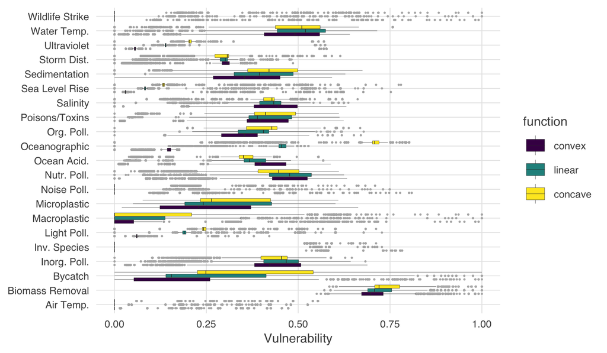

```r
df_long <- df %>%
  select(tx_lbl, str_lbl, species,
         linear = vuln, convex = v_conv, concave = v_conc) %>%
  gather(shape, vuln, -tx_lbl, -str_lbl, -species) %>%
  mutate(shape = factor(shape, levels = c('convex', 'linear', 'concave')))

p <- ggplot(df_long, aes(x = str_lbl, y = vuln)) +
  theme_ohara() +
  theme(axis.title.y = element_blank()) +
  geom_boxplot(aes(fill = shape), size = .1,
               outlier.size = .1, outlier.color = 'grey70') +
  scale_fill_viridis_d() +
  coord_flip() +
  labs(#title = 'Vulnerability by stressor and score function',
       fill = 'function', y = 'Vulnerability')

ggsave('figs/si_sensitivity_str.png', height = 3.5, width = 6, dpi = 300)
knitr::include_graphics('figs/si_sensitivity_str.png')
```

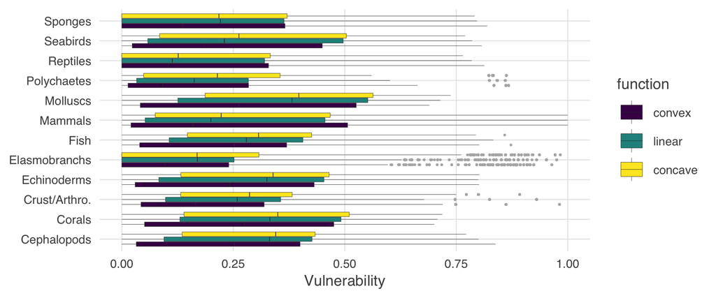

```r
p <- ggplot(df_long, aes(x = tx_lbl, y = vuln)) +
  theme_ohara() +
  theme(axis.title.y = element_blank()) +
  geom_boxplot(aes(fill = shape), size = .1,
               outlier.size = .1, outlier.color = 'grey70') +
  scale_fill_viridis_d() +
  coord_flip() +
  labs(#title = 'Vulnerability by taxon and score function',
       fill = 'function', y = 'Vulnerability')

ggsave('figs/si_sensitivity_tx.png', height = 2.5, width = 6, dpi = 300)
knitr::include_graphics('figs/si_sensitivity_tx.png')
```

### 6.1.1 RMS score differences

Use an RMSE approach to determine the amount that these scoring strategies change the vulnerability scores.

```r
rmse_by_stressor <- df %>%
  group_by(str_lbl) %>%
  summarize(mean_vuln_lin = mean(vuln),
            rmse_v_conc = sqrt(sum((vuln - v_conc)^2) / n()),
            rmse_v_conv = sqrt(sum((vuln - v_conv)^2) / n()),
            rmse_sd_conc = sqrt(sum((sd_vuln - sd_conc)^2, na.rm = TRUE) / n()),
            rmse_sd_conv = sqrt(sum((sd_vuln - sd_conv)^2, na.rm = TRUE) / n()),
            .groups = 'drop')

rmse_by_taxon <- df %>%
  group_by(tx_lbl) %>%
  summarize(mean_sd_lin = sqrt(sum(sd_vuln^2, na.rm = TRUE) / n()),
            rmse_v_conc = sqrt(sum((vuln - v_conc)^2) / n()),
            rmse_v_conv = sqrt(sum((vuln - v_conv)^2) / n()),
            rmse_sd_conc = sqrt(sum((sd_vuln - sd_conc)^2, na.rm = TRUE) / n()),
            rmse_sd_conv = sqrt(sum((sd_vuln - sd_conv)^2, na.rm = TRUE) / n()),
            .groups = 'drop')
```

## 6.2 RMS change in % rank

Would it make more sense to use RMSE on the ranking of each species in the set (by stressor)? So if looking at a particular stressor, a species is ranked 100 out of 22,000+ species, and after is ranked 104, that’s not a huge swing.

Here, arrange low to high, so top rank is a low vulnerability. Use `percent_rank()` to normalize rank by number of observations, to be between 0 and 1.

```r
rmse_rank_by_stressor <- df %>%
  select(-starts_with('sd_')) %>%
  group_by(str_lbl) %>%
  mutate(rank_linear  = percent_rank(vuln),
         rank_convex  = percent_rank(v_conv),
         rank_concave = percent_rank(v_conc)) %>%
  summarize(mean_rank_lin = mean(rank_linear),
            mean_abs_conc  = mean(abs(rank_linear - rank_concave)),
            mean_abs_conv  = mean(abs(rank_linear - rank_convex)),
            rmse_rank_conc = sqrt(sum((rank_linear - rank_concave)^2) / n()),
            rmse_rank_conv = sqrt(sum((rank_linear - rank_convex)^2) / n()),
            .groups = 'drop')

rmse_rank_by_taxon <- df %>%
  group_by(tx_lbl) %>%
  mutate(rank_linear  = percent_rank(vuln),
         rank_convex  = percent_rank(v_conv),
         rank_concave = percent_rank(v_conc)) %>%
  summarize(mean_rank_lin = mean(rank_linear),
            mean_abs_conc  = mean(abs(rank_linear - rank_concave)),
            mean_abs_conv  = mean(abs(rank_linear - rank_convex)),
            rmse_rank_conc = sqrt(sum((rank_linear - rank_concave)^2) / n()),
            rmse_rank_conv = sqrt(sum((rank_linear - rank_convex)^2) / n()),
            .groups = 'drop')
```

### 6.2.1 RMSE of rank by stressor

|  | str_lbl | mean_rank_lin | mean_abs_conc | mean_abs_conv | rmse_rank_conc | rmse_rank_conv |
| --- | --- | --- | --- | --- | --- | --- |
| 1 | Air Temp. | 0.0845346119012628 | 0.000169723964438406 | 3.51612269848371e-05 | 0.00117023464765307 | 0.000457205479853394 |
| 2 | Biomass Removal | 0.453922433696042 | 0.0316464322719692 | 0.0528657746122617 | 0.0605202138457621 | 0.0974772961753283 |
| 3 | Bycatch | 0.467032740970208 | 0.0264880963257847 | 0.0431324505660821 | 0.0539637681285749 | 0.0836284872329668 |
| 4 | Inorg. Poll. | 0.48356569193252 | 0.0398606035545798 | 0.064016565536779 | 0.0704114009231663 | 0.104708346852393 |
| 5 | Inv. Species | 0.00573443620972764 | 1.50235290183216e-06 | 2.16571065655432e-06 | 2.95765165980762e-05 | 4.20654136174586e-05 |
| 6 | Light Poll. | 0.460997392002092 | 0.0248071646495726 | 0.0449781654978537 | 0.0535006350420946 | 0.09203950148125 |
| 7 | Macroplastic | 0.343124093891365 | 0.000740731832263817 | 0.000439370000997169 | 0.00421241873671974 | 0.00435506925728726 |
| 8 | Microplastic | 0.483609905198625 | 0.0512987134839342 | 0.0629399747297928 | 0.072886617923163 | 0.0804016188332932 |
| 9 | Noise Poll. | 0.0530532272481596 | 0.000285884693280398 | 7.05314769821063e-05 | 0.00182808530443362 | 0.000807352646914775 |
| 10 | Nutr. Poll. | 0.484152353845829 | 0.0273361622007051 | 0.0392422686672493 | 0.0443231499869215 | 0.0623851293173013 |

[output cut: 11 more lines]

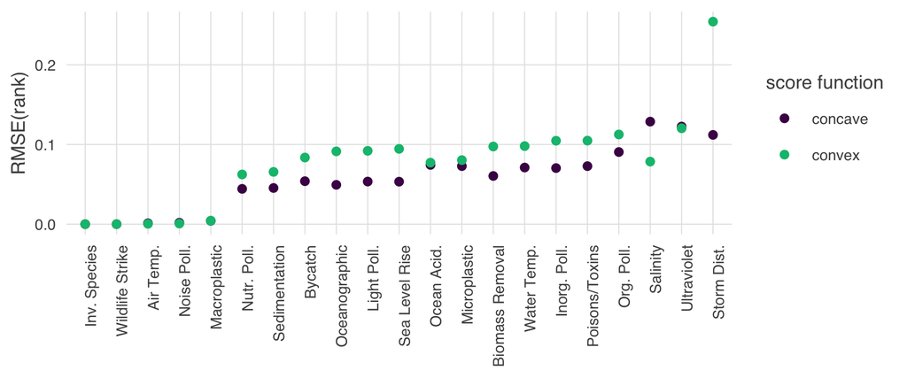

```r
plot_str_df <- rmse_rank_by_stressor %>%
  select(str_lbl, starts_with('rmse_rank')) %>%
  gather(score_f, rmse_rank, -str_lbl) %>%
  mutate(score_f = ifelse(score_f == 'rmse_rank_conc', 'concave', 'convex')) %>%
  group_by(str_lbl) %>%
  mutate(mean_rmse_rank = mean(rmse_rank)) %>%
  arrange(mean_rmse_rank) %>%
  ungroup() %>%
  mutate(str_lbl = fct_inorder(str_lbl))

p <- ggplot(plot_str_df, aes(x = str_lbl, y = rmse_rank, color = score_f)) +
  geom_point() +
  theme_ohara() +
  theme(axis.text.x = element_text(angle = 90, hjust = 1),
        axis.title.x = element_blank()) +
  scale_color_manual(values = c("#4B0055", "#00BE7D")) +
  labs(y = 'RMSE(rank)',
       color = 'score function')
ggsave('figs/si_sensitivity_rank_str.png', height = 2.5, width = 6, dpi = 300)
knitr::include_graphics('figs/si_sensitivity_rank_str.png')
```

### 6.2.2 RMSE of rank by stressor and taxon

|  | tx_lbl | mean_rank_lin | mean_abs_conc | mean_abs_conv | rmse_rank_conc | rmse_rank_conv |
| --- | --- | --- | --- | --- | --- | --- |
| 1 | Cephalopods | 0.48160206160888 | 0.0436734498681545 | 0.0590943198611905 | 0.0622708119213877 | 0.107146750393707 |
| 2 | Corals | 0.463124979275428 | 0.0401370797000036 | 0.0442282578232136 | 0.0707892234417187 | 0.0773176649860999 |
| 3 | Crust/Arthro. | 0.473556895319537 | 0.0534688486278559 | 0.0621141977708331 | 0.0814924490261579 | 0.0906330132076821 |
| 4 | Echinoderms | 0.473446027738891 | 0.036377770304446 | 0.0473178166458523 | 0.0597249538661893 | 0.0886877054444224 |
| 5 | Elasmobranchs | 0.448486678584274 | 0.0267597599229184 | 0.0495248324488335 | 0.0481849823489506 | 0.0944284555391652 |
| 6 | Fish | 0.476995648228673 | 0.0299349378453157 | 0.0325089496913279 | 0.0540175736306816 | 0.0597516931265035 |
| 7 | Mammals | 0.477329735256006 | 0.0213767675280532 | 0.0287171013225769 | 0.0356832583696954 | 0.0503792308414586 |
| 8 | Molluscs | 0.470015552814887 | 0.033354483847373 | 0.0310919127416035 | 0.0512303216325503 | 0.0507415088794604 |
| 9 | Polychaetes | 0.465477031419187 | 0.0394337812330468 | 0.0485518920950267 | 0.0601074812554352 | 0.0827058545685092 |
| 10 | Reptiles | 0.443692209062441 | 0.015487628801017 | 0.0167783101964104 | 0.0308876724240987 | 0.033859612674811 |

[output cut: 2 more lines]

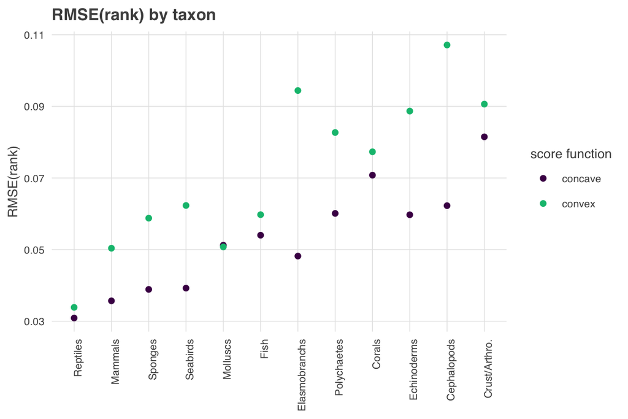

```r
plot_str_tx_df <- rmse_rank_by_taxon %>%
  select(tx_lbl, starts_with('rmse_rank')) %>%
  gather(score_f, rmse_rank, -tx_lbl) %>%
  mutate(score_f = ifelse(score_f == 'rmse_rank_conc', 'concave', 'convex')) %>%
  group_by(tx_lbl) %>%
  mutate(mean_rmse_rank = mean(rmse_rank)) %>%
  arrange(mean_rmse_rank) %>%
  ungroup() %>%
  mutate(tx_lbl = fct_inorder(tx_lbl))

ggplot(plot_str_tx_df, aes(x = tx_lbl, y = rmse_rank, color = score_f)) +
  geom_point() +
  theme_ohara() +
  theme(axis.text.x = element_text(angle = 90, hjust = 1),
        axis.title.x = element_blank()) +
  scale_color_manual(values = c("#4B0055", "#00BE7D")) +
  labs(y = 'RMSE(rank)',
       color = 'score function',
       title = 'RMSE(rank) by taxon')
```

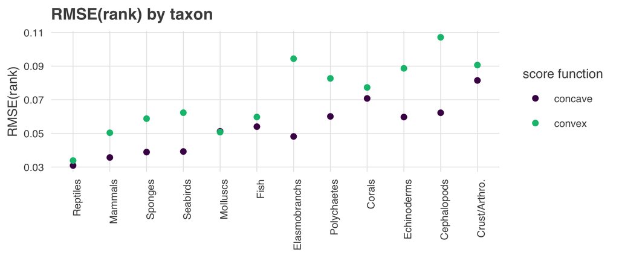

```r
ggsave('figs/si_sensitivity_rank_tx.png', height = 2.5, width = 6, dpi = 300)
knitr::include_graphics('figs/si_sensitivity_rank_tx.png')
```